# How Consequentialist Reasoning Shapes Bioethical Views

Piotr Bystranowski, Jon Rueda, & Ivar R. Hannikainen

2022-02-08

1. the absolute value of the Pearson’s correlation coefficient between responses regarding the normative and factual statements in a given pair exceeds .3;
2. the distribution of responses regarding the normative (and, to a smaller extent, factual) statement in a given pair resembles a bimodal distribution;
3. the responses regarding the normative (and, to a smaller extent, factual) statement in a given pair exhibit some correlation with political attitudes on the social dimension (a single-item measure).

Seven selected pairs of normative-factual statements (before reverse-scoring)

| Issue | Type | Mean | SD | Fact-Norm correlation | Shapiro-Wilk test | Correlation with politics |
| --- | --- | --- | --- | --- | --- | --- |
| Abortion | Factual | 48.70 | 27.70 | -0.59 | 0.95 | -0.30 |
| Abortion | Normative | 55.28 | 29.81 | -0.59 | 0.95 | 0.35 |
| Animals in Research | Factual | 55.37 | 30.21 | 0.77 | 0.92 | 0.15 |
| Animals in Research | Normative | 47.33 | 29.65 | 0.77 | 0.94 | 0.12 |
| GM Crops | Factual | 61.67 | 22.54 | -0.77 | 0.96 | -0.08 |
| GM Crops | Normative | 35.38 | 26.79 | -0.77 | 0.94 | 0.21 |
| Sexual Assistance | Factual | 64.70 | 21.83 | 0.36 | 0.92 | -0.23 |
| Sexual Assistance | Normative | 44.75 | 25.93 | 0.36 | 0.96 | -0.30 |
| Surrogacy | Factual | 46.28 | 21.00 | -0.34 | 0.96 | -0.10 |
| Surrogacy | Normative | 76.44 | 23.28 | -0.34 | 0.86 | -0.21 |
| Transgender Teen | Factual | 83.22 | 15.72 | 0.53 | 0.90 | 0.20 |
| Transgender Teen | Normative | 67.62 | 32.43 | 0.53 | 0.86 | 0.53 |
| Vaccines | Factual | 22.23 | 20.83 | 0.46 | 0.88 | 0.26 |
| Vaccines | Normative | 51.15 | 31.12 | 0.46 | 0.94 | 0.20 |

To allow for a consistent and meaningful interpretation of the employed measures in the studies to follow, we chose to reverse-score some items, employing the following criteria:

- reverse-score *normative* statements so that all of them correlate positively with the measure of social political attitudes (so that a higher score for a given item indicates social conservatism of the respondent);
- reverse-score *factual* statements so that all of them correlate positively with the corresponding normative statement,

  Interpretation of employed items, after reverse-scoring. Statements in brown are reverse-scored when compared to the version seen by participants

  | Issue | Normative | Factual |
  | --- | --- | --- |
  | Abortion | The human fetus has a right to life. | The human fetus is capable of experiencing pain [by the second trimester or earlier]. |
  | Animals in Research | Animal testing (e.g., with mice, rabits, guinea pigs) in biomedical research is morally acceptable. | Animal testing is necessary to guarantee the safety of biomedical developments. |
  | GM Crops | Governments should ban all genetically modified crops developed for human consumption. | Genetically modified crops are unfit for human consumption. |
  | Sexual Assistance | Governments shoud not subsidize sexual assistance to meet the needs of disabled individuals. | Paid sexual assistance would not help meet the needs of disabled individuals |
  | Surrogacy | Surrogate motherhood should be illegal. | It is likely that surrogate mothers are being exploited. |
  | Transgender Teens | Parents should be allowed to veto transgender teens’ choice to undergo certain medical procedures (e.g., to receive puberty blocking drugs | The average teenager is mature enough to decide whether to undergo irreversible surgeries [at 15 years of age or later]. |
  | Vaccines | If a parent is concerned about vaccinating their children, they should have the right to refuse to vaccinate them. | The side-effects caused by modern vaccines are frequent and severe. |

  Following that, we fitted a series of mixed-effect models on the recoded data, with the random effect of participant and issue. The effect of participant identifying as right-wing or left-wing was massive for factual statements ($\beta$ = 6.76, *t*(134) = 4.15, *p* = < 0.001) and even larger for normative statements ($\beta$ = 14.41, *t*(136) = 7.17, *p* = < 0.001). Finally, it turned out that normative statements are predicted by both the corresponding factual statements ($\beta$ = 0.63, *t*(1861) = 26.91, *p* < 0.001) and self-reported social political views (single-item measure; $\beta$ = 3, *t*(141) = 6.98, *p* < 0.001).

Having selected the 7 items, we collected data on the respective factual beliefs of the expert community by soliciting responses from 32 bioethicists specializing in at least one of seven issues included in our study. Having recoded their factual responses analogically to those of the lay sample, we did not find any evidence that being an expert predicted any systematic difference in factual opinions ($\beta$ = -0.23, *t*(165) = -0.11, *p* = 0.91), nor that the level of consensus among experts was systematically different from that among lay people (measured by the mean absolute deviation from a given sample’s median; ($\beta$ = 0.01, *t*(164) = 0.26, *p* = 0.79)). On the level of specific issues, we observed differences in factual opinions between experts and laypeople for: *Surrogacy* (t(47) = 5.75, *p* < 0.001); *GM Crops* (t(47) = -3.61, *p* < 0.001); *Animals in Research* (t(49) = 2.1, *p* = 0.041); *Transgender Teen* (t(39) = -2.71, *p* = 0.01).

## Study 1a: Consequentialist Reflection

In this exploratory study, we examined the effect of reflection by asking study participants to reflect on a given issue and produce a short argumentative text. We employed a set of normative/factual statement pairs regarding 7 notable, possibly morally controversial issues. We examined the effect of reflection by asking participants to express (on a closed scale) their attitude towards each of the 7 normative statements twice. Before the second time, they were also asked to ponder a factual statement (matching one of the normative statements) and write a short description of arguments they would use to support their view on that factual statement.

### Methods

146 U.K. nationals recruited on Prolific completed both parts of the study (Age = 34 years; 83 women; 65 participants declared right-wing political views). The study consisted of two sessions. In the first session, participants were asked to express their attitude towards each of the seven factual or normative (depending on condition) statements using a 100-point slider labeled at both extremes and both tertiles. For each statement, participants were also asked to express their confidence in the provided answer. They also answered a few basic demographic questions. After a seven-day delay, participants returned to take part in the second wave of the study. Each participant was presented with one randomly selected factual (Reflection condition) statement, and were asked to reflect for at least 45 seconds on what they believe and the reasons for believing it. Participants recorded their attitude on a 100-point soldier. They were informed that they would be asked to explain their point of view to others. On the next screen, participants were asked to explain their point of view in a text box. After that, participants were presented with the same 7 statements as in the first session and asked to express their attitudes to each of them.

### Analysis plan

~~Assuming that we would observe some effects of reflection, we also wanted to check if those effects are symmetric or asymmetric.

Hypothesis 1. *An asymmetric outcome, in contrast, would be observed if the cognitive effort invested in reflection and/or rationalization overall shifts the population judgment in one direction, making it, say, more progressive rather than conservative.*

We calculated the difference between post- and pre-treatment assessments of a given participant for a given issue. As the measures for all items were rescaled to correlate with conservative views, a negative difference would indicate a post-treatment left-ward shift, while a positive difference would be associated with a rightward shift.

Hypothesis 2. *A possible symmetric setting is one in which the effect moderates extreme attitudes and beliefs. And so, reflecting on a factual statement regarding a given issue, people might realize they are uncertain on whether a given activity is (or is not) harmful, thus they might moderate their moral assessment of this issue.*

If the effect of our manipulation were to be symmetric (increased or decreased polarization), then we would expect to observe a change in the deviations from the median. Hence, we calculated the absolute deviation of every observation from the (grand) median for a given item. We then calculated the difference between post- and pre-treatment absolute deviations for each participant/item. The resulting measure would take a positive value if the manipulation resulted in an increased polarization and a negative value in the case of a moderation. Finally, we aimed to check whether the effects of reflection/rationalization are general or domain-specific. In the adopted design, we measured the change in beliefs and attitudes regarding 7 issues, while asking participants to perform the rationalization/reflection task only on one of them. This allowed us to check if any observed effect took place only with regard to the target issue, or also for the other 6 filler issues.~~

### Results

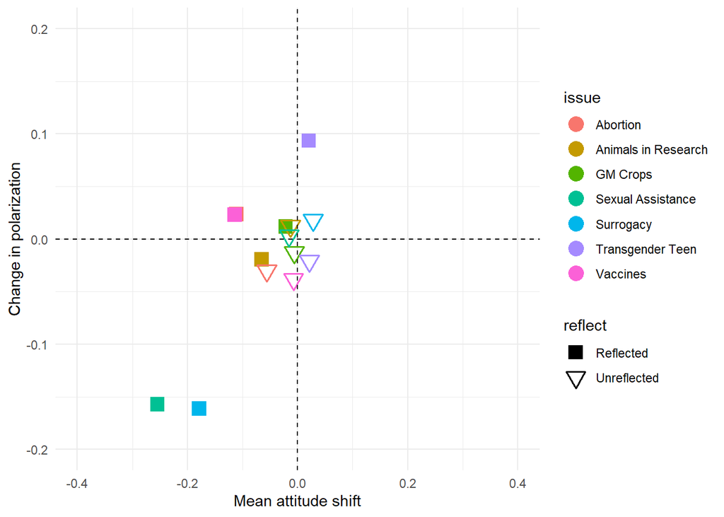

First, we standardized the responses within each issue subset by calculating the number of interquartile ranges a given response is from the median assessment of a given statment ($x_{standardized} = \frac{x - median}{IQR}$; e.g., for normative statement the standardized response equal to -0.5 would respresent the first quartile, that is, a typically progressive response) and, second, we calculated the difference between standardized responses given in session 2 and session 1 (so that a positive difference would indicate a shift in the conservative direction on the social political scale). Then, we fitted a series of mixed-effect models with the said difference as the dependent measure and random effects of participant’s id and issue. An intercept-only model revealed a non-significant negative intercept ($\beta$ = -0.02, *t*(999) = -1.58, *p* = 0.11). Thus, we didn’t observe evidence that reflecting on one issue would lead to a consistent shift in normative opinions on all 7 issues. However, adding the effect of reflection (i.e, a binary variable indicating whether a given issue was the reflection topic or merely one of 6 filler issues for a given participant) improved the models fit ($\chi^2$(1) = 6.45), *p* = 0.011), thus suggesting that reflecting on the factual dimension of a given issue would move the normative opinions on that issue in the direction of political progressivism ($\beta$ = -0.1, *t*(998) = -2.54, *p* = 0.011).

In the second set of analyses, the dependent measure was the change in the normalized distance from the median (with a positive score indicating enhanced polarization). Again, we fitted a series of mixed-effect models, with an intercept-only model providing some inconclusive evidence of the moderating effect of reflection across the seven issues ($\beta$ = -0.01, *t*(140) = -1.24, *p* = 0.22). As adding the effect of reflection didn’t improve the model’s fit ($\chi^2$(1) = 0.35), *p* = 0.55), the putative moderating effect of reflection doesn’t seem to be enhanced by focusing on the target issue.

## Study 1b: Rationalization

144 U.K. nationals recruited on Prolific completed both parts of the study (Age = 38 years; 91 women; 60 participants declared right-wing political views).

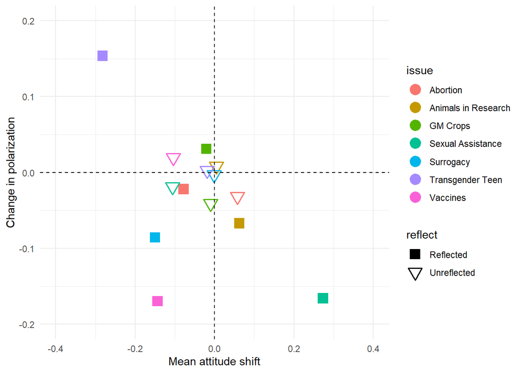

### Results

We conducted a series of analyses analogical to that from Study 1a. So, first, we fitted a series of mixed-effect models with the difference between normalized assessments of factual statement in the second and first series as the dependent measure and random effects of participant’s id and issue. An intercept-only model revealed a non-significant negative intercept ($\beta$ = -0.03, *t*(6) = -1.53, *p* = 0.18) and the mode’s fit wasn’t improved by adding the effect of target issue ($\chi^2$(1) = 0.12), *p* = 0.73), meaning that we didn’t observe evidence that thinking about the normative dimension of one issue would lead to a consistent shift in factual beliefs on all 7 issues, nor a shift in specific factual beliefs on the target issue.

## Discussion

Study 1 suggested that reflection plays a potentially important role in shaping bioethical views: Reflecting on the factual aspects of a given bioethical issue can impact the corresponding normative attitudes in some important respects. We see that, on average, such reflection moves the normative attitudes on a given issue in the direction more associated with progressive views (but we don’t observe evidence that the same effect takes place also for “unreflected” issues). On the other hand, we see no evidence that such reflection moderates normative opinions, in the sense of bringing them closer to each other. Finally, we see some preliminary evidence that reflection seems to increase consequentialist attitudes in the sense of greater association between one’s normative and factual beliefs. However, due to the limitations of the current study’s setting, we could observe evidence of such an effect only for the ‘reflected’ issues. To address this shortcoming, we designed Study 2.

## Study 2

Autoregression: the shift in factual beliefs predicts normative response in session 2 independently of the normative response from study 1 ($\beta$ = 0.12, *t*(573) = 4.39, *p* < 0.001). The degree of this dependence seems to vary across issues, though:

| issue | prior | pvalue1 | factual_shift | pvalue2 |
| --- | --- | --- | --- | --- |
| Abortion | 0.86 | < 0.001 | -0.10 | 0.17 |
| Animals in Research | 0.86 | < 0.001 | 0.29 | < 0.001 |
| GM Crops | 0.86 | < 0.001 | 0.24 | < 0.001 |
| Sexual Assistance | 0.59 | < 0.001 | 0.16 | 0.07 |
| Surrogacy | 0.63 | < 0.001 | 0.22 | 0.009 |
| Transgender Teen | 0.89 | < 0.001 | 0.01 | 0.84 |
| Vaccines | 0.73 | < 0.001 | -0.01 | 0.93 |

We also check if beliefs for target issues are less dispersed in session 1 than in session 2. We didn’t observe any evidence of such a systematic tendency for factual beliefs ($\beta$ = 0.03, *t*(1228) = 1.21, *p* = 0.23), nor for normative attitudes ($\beta$ = 0, *t*(1202) = 0.07, *p* = 0.95). Again, it appears that reflection doesn’t moderate people’s opinions in the sense of bringing them closer together.